# ISLR2 Chapter 3 - Linear Regression Lab Exercises

Ricardo J. Serrano

January 6, 2021

# Lab: Linear Regression

- Supervised learning (target)
- OLS (Ordinary Least Squares)
- Simple, yet extremely useful and easy to explain

[figure not shown]

# Libraries

Comment: Due to the recent controversies related to the `housing` dataset, we’ll use an alternate [housing dataset](https://www.kaggle.com/anthonypino/melbourne-housing-market/code)

```r
# library(MASS)
library(ISLR2)
library(dplyr)
```

If you receive an error message when loading any of these libraries, it likely indicates that the corresponding library has not yet been installed on your system. Some libraries, such as `MASS`, come with `R` and do not need to be separately installed on your computer. However, other packages, such as `ISLR2`, must be downloaded the first time they are used. This can be done directly from within `R`. For example, on a Windows system, select the `Install package` option under the `Packages` tab. After you select any mirror site, a list of available packages will appear. Simply select the package you wish to install and `R` will automatically download the package. Alternatively, this can be done at the `R` command line via `install.packages("ISLR2")`. This installation only needs to be done the first time you use a package. However, the `library()` function must be called within each `R` session.

# Simple Linear Regression

Melbourne Housing Market Kaggle Dataset

The dataset we’ll be using for the ISLR2 lab exercises is a subset, clean dataset from the original.

*Features:*

`price`: Price in Australian dollars

`type`: h - house, cottage, villa, semi, terrace; u - unit, duplex; t - townhouse

`method`: S - property sold; SP - property sold prior; PI - property passed in; VB - vendor bid; SA - sold after auction

`council_area`: Governing council for the area

`distance`: Distance from CBD (Center Business District) in Kilometers

`car`: Number of carspots

`year`, `month`, `day`: extracted from `Date` - date sold

`Lattitude`: Self explanatory

`Longtitude`: Self explanatory

# Read the dataset

```r
housing <- readr::read_csv('./melbourne_housing_imp.csv') %>%
  janitor::clean_names()
```

```r
head(housing)
```

```
## # A tibble: 6 x 13
##     price type  method council_area      rooms distance bathroom   car lattitude
##     <dbl> <chr> <chr>  <chr>             <dbl>    <dbl>    <dbl> <dbl>     <dbl>
## 1 1480000 h     S      Yarra City Counc~     2      2.5        1     1     -37.8
## 2 1035000 h     S      Yarra City Counc~     2      2.5        1     0     -37.8
## 3 1465000 h     SP     Yarra City Counc~     3      2.5        2     0     -37.8
## 4  850000 h     PI     Yarra City Counc~     3      2.5        2     1     -37.8
## 5 1600000 h     VB     Yarra City Counc~     4      2.5        1     2     -37.8
## 6  941000 h     S      Yarra City Counc~     2      2.5        1     0     -37.8
## # ... with 4 more variables: longtitude <dbl>, year <dbl>, month <dbl>,
## #   day <dbl>
```

# Fit a linear regression model - lm()

```r
lm.fit <- lm(price ~ distance)
```

```
## Error in eval(predvars, data, env): object 'price' not found
```

The command causes an error because `R` does not know where to find the variables `price` and `distance`. The next line tells `R` that the variables are in `housing`. If we attach `housing`, the first line works fine because `R` now recognizes the variables.

```r
lm.fit <- lm(price ~ distance, data = housing)
attach(housing)
lm.fit <- lm(price ~ distance)
```

If we type `lm.fit`, some basic information about the model is output. For more detailed information, we use `summary(lm.fit)`. This gives us $p$-values and standard errors for the coefficients, as well as the $R^2$ statistic and $F$-statistic for the model.

```r
lm.fit
```

```
##
## Call:
## lm(formula = price ~ distance)
##
## Coefficients:
## (Intercept)     distance
##     1343119       -22306
```

```r
summary(lm.fit)
```

```
##
## Call:
## lm(formula = price ~ distance)
##
## Residuals:
##      Min       1Q   Median       3Q      Max
## -1115361  -385750  -145449   234547 10091093
##
## Coefficients:
##              Estimate Std. Error t value Pr(>|t|)
## (Intercept) 1343118.6     8445.4  159.03   <2e-16 ***
## distance     -22305.8      635.7  -35.09   <2e-16 ***
## ---
## Signif. codes:  0 '***' 0.001 '**' 0.01 '*' 0.05 '.' 0.1 ' ' 1
##
## Residual standard error: 634700 on 20991 degrees of freedom
## Multiple R-squared:  0.05541,    Adjusted R-squared:  0.05537
## F-statistic:  1231 on 1 and 20991 DF,  p-value: < 2.2e-16
```

# Regression model plot

Using `ggpubr` library to visualize the regression model line, regression equation and $R^2$

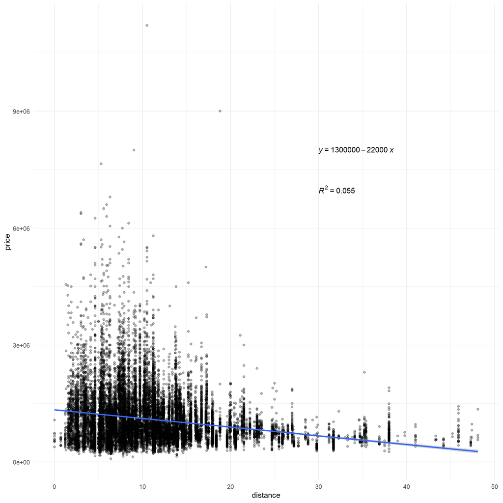

```r
library(ggpubr)

housing %>%
     ggplot(aes(x = distance, y = price)) +
     geom_point(alpha = 0.3) +
     geom_smooth(method = "lm") +
     stat_regline_equation(label.x = 30, label.y = 8e+06) + # for regression equation
     stat_cor(aes(label = ..rr.label..), label.x = 30, label.y = 7e+06) + # for R^2
     theme_minimal()
```

# lm.fit

We can use the `names()` function in order to find out what other pieces of information are stored in `lm.fit`. Although we can extract these quantities by name—e.g. `lm.fit$coefficients`—it is safer to use the extractor functions like `coef()` to access them.

```r
names(lm.fit)
```

```
##  [1] "coefficients"  "residuals"     "effects"       "rank"
##  [5] "fitted.values" "assign"        "qr"            "df.residual"
##  [9] "xlevels"       "call"          "terms"         "model"
```

```r
coef(lm.fit)
```

```
## (Intercept)    distance
##  1343118.64   -22305.84
```

In order to obtain a confidence interval for the coefficient estimates, we can use the `confint()` command. %Type `confint(lm.fit)` at the command line to obtain the confidence intervals.

```r
confint(lm.fit)
```

```
##                  2.5 %     97.5 %
## (Intercept) 1326564.97 1359672.32
## distance     -23551.79  -21059.89
```

The intercept value 1,343,118.64 is the expected `price` when `distance` is equal to 0. Let’s fit a model with a more interpretable intercept by centering our independent variable:

```r
lm_fit_distance_mean <- lm(price ~ I(distance - mean(distance)))
coef(lm_fit_distance_mean)
```

```
##                  (Intercept) I(distance - mean(distance))
##                   1089746.18                    -22305.84
```

The new intercept (1,089,746.18) is the expected `price` of the average `distance` (11.359 km). Notice the estimated slope didn’t change.

The `predict()` function can be used to produce confidence intervals and prediction intervals for the prediction of `price` for a given value of `distance`.

```r
predict(lm.fit, data.frame(distance = (c(10, 20, 30))),
    interval = "confidence")
```

```
##         fit       lwr       upr
## 1 1120060.2 1111308.7 1128811.8
## 2  897001.9  883231.1  910772.6
## 3  673943.5  649181.4  698705.5
```

```r
predict(lm.fit, data.frame(distance = (c(10, 20, 30))),
    interval = "prediction")
```

```
##         fit       lwr     upr
## 1 1120060.2 -124018.3 2364139
## 2  897001.9 -347122.1 2141126
## 3  673943.5 -570350.7 1918238
```

For instance, the 95,% confidence interval associated with a `distance` value of 20 is $(883231.1, 910772.6)$, and the 95,% prediction interval is $(-347122.1, 2141126)$. As expected, the confidence and prediction intervals are centered around the same point (a predicted value of $897001.9$ for `price` when `distance` equals 20), but the latter are substantially wider.

We will now plot `price` and `distance` along with the least squares regression line using the `plot()` and `abline()` functions.

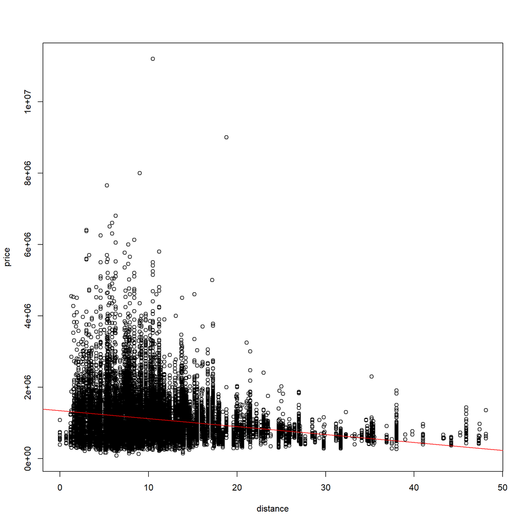

```r
plot(distance, price)
abline(lm.fit, col = 'red')
```

There is some evidence for non-linearity in the relationship between `distance` and `price`. We will explore this issue later in this lab.

# Diagnostic Plots

Next we examine some diagnostic plots, several of which were discussed in Section 3.3.3. Four diagnostic plots are automatically produced by applying the `plot()` function directly to the output from `lm()`. In general, this command will produce one plot at a time, and hitting *Enter* will generate the next plot. However, it is often convenient to view all four plots together. We can achieve this by using the `par()` and `mfrow()` functions, which tell `R` to split the display screen into separate panels so that multiple plots can be viewed simultaneously. For example, `par(mfrow = c(2, 2))` divides the plotting region into a $2 \times 2$ grid of panels.

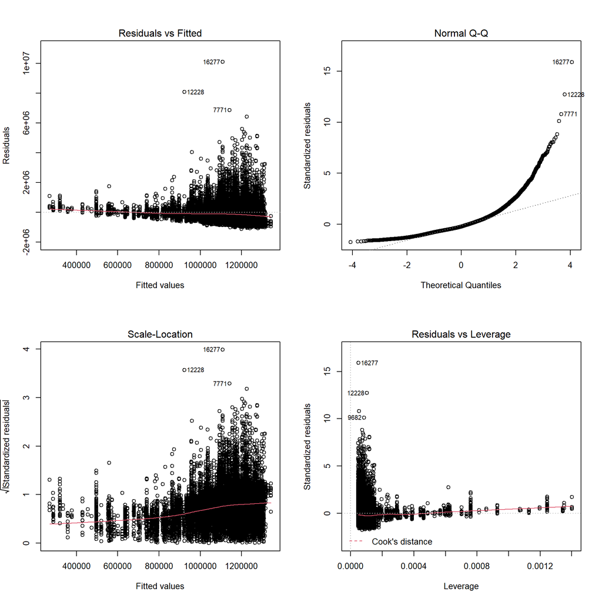

```r
par(mfrow = c(2, 2))
plot(lm.fit)
```

Alternatively, we can compute the residuals from a linear regression fit using the `residuals()` function. The function `rstudent()` will return the studentized residuals, and we can use this function to plot the residuals against the fitted values.

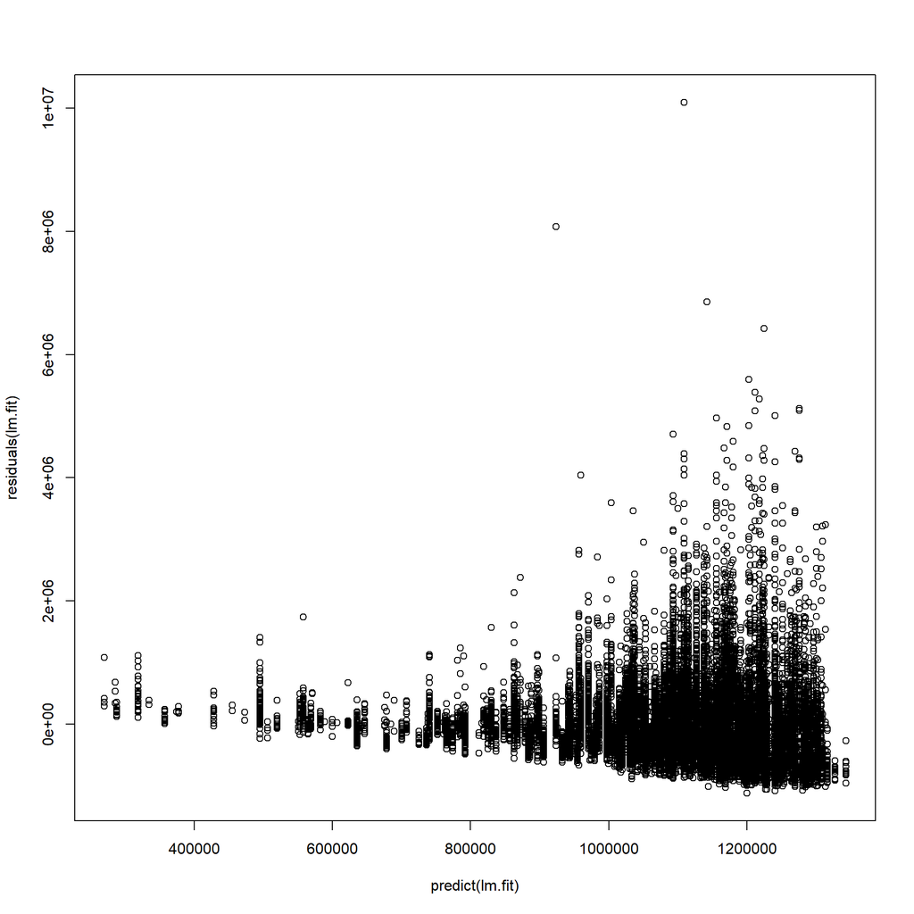

```r
plot(predict(lm.fit), residuals(lm.fit))
```

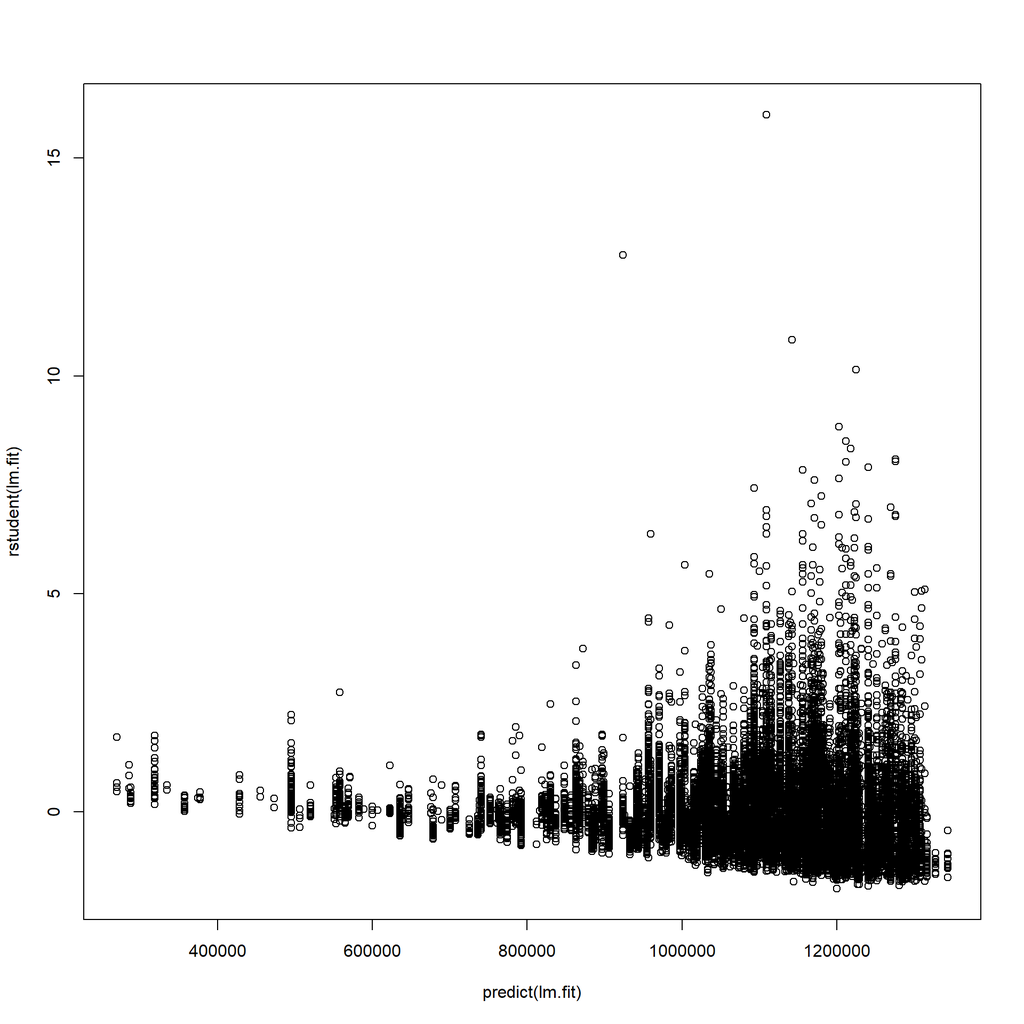

```r
plot(predict(lm.fit), rstudent(lm.fit))
```

On the basis of the residual plots, there is some evidence of non-linearity. Leverage statistics can be computed for any number of predictors using the `hatvalues()` function.

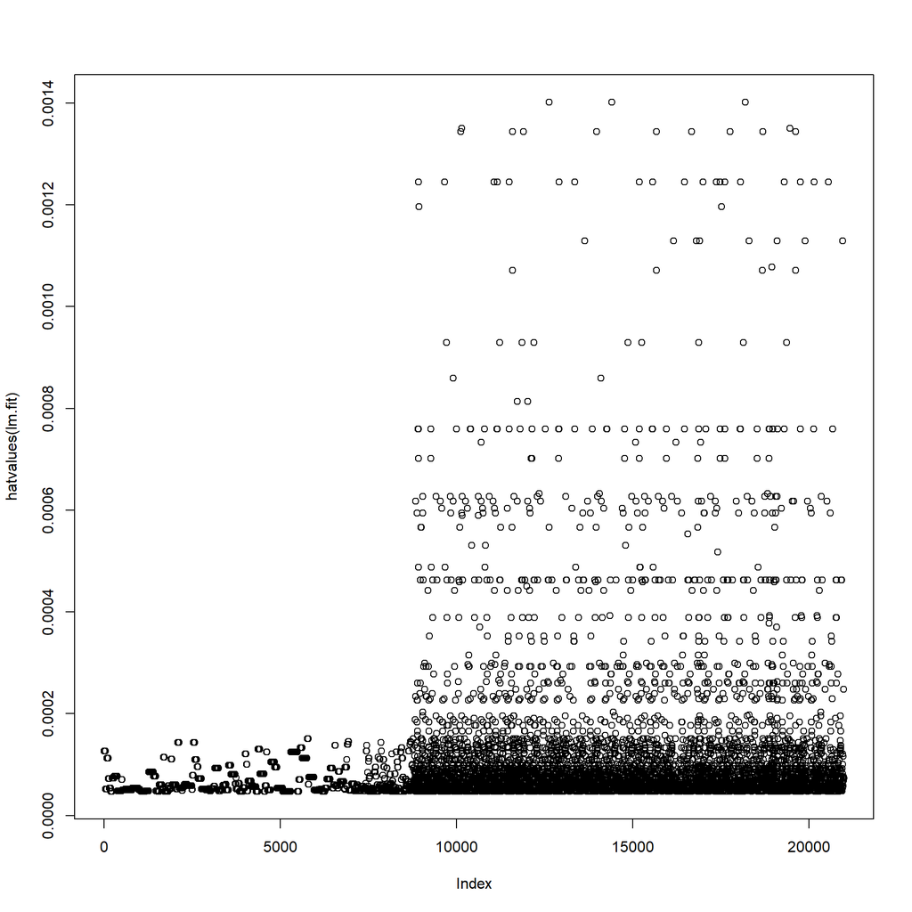

```r
plot(hatvalues(lm.fit))
```

```r
which.max(hatvalues(lm.fit))
```

```
## 12633
## 12633
```

The `which.max()` function identifies the index of the largest element of a vector. In this case, it tells us which observation has the largest leverage statistic.

# Multiple Linear Regression

```r
lm.fit <- lm(price ~ distance + rooms, data = housing)
summary(lm.fit)
```

```
##
## Call:
## lm(formula = price ~ distance + rooms, data = housing)
##
## Residuals:
##      Min       1Q   Median       3Q      Max
## -3040188  -319587   -95314   207541  9719578
##
## Coefficients:
##             Estimate Std. Error t value Pr(>|t|)
## (Intercept) 341848.5    12681.8   26.96   <2e-16 ***
## distance    -36913.0      553.3  -66.72   <2e-16 ***
## rooms       381540.2     4014.0   95.05   <2e-16 ***
## ---
## Signif. codes:  0 '***' 0.001 '**' 0.01 '*' 0.05 '.' 0.1 ' ' 1
##
## Residual standard error: 530700 on 20990 degrees of freedom
## Multiple R-squared:  0.3397, Adjusted R-squared:  0.3396
## F-statistic:  5398 on 2 and 20990 DF,  p-value: < 2.2e-16
```

The `housing` data set contains 13 variables, and so it would be cumbersome to have to type all of these in order to perform a regression using all of the predictors. Instead, we can use the following short-hand:

```r
lm.fit <- lm(price ~ ., data = housing)
summary(lm.fit)
```

```
##
## Call:
## lm(formula = price ~ ., data = housing)
##
## Residuals:
##      Min       1Q   Median       3Q      Max
## -1742844  -214484   -40073   149718  8989318
##
## Coefficients:
##                                              Estimate Std. Error t value
## (Intercept)                                -1.338e+08  1.700e+07  -7.872
## typet                                      -3.423e+05  1.088e+04 -31.456
## typeu                                      -5.335e+05  9.116e+03 -58.519
## methodS                                     7.374e+04  8.887e+03   8.297
## methodSA                                    2.054e+04  3.391e+04   0.606
## methodSP                                    3.725e+04  1.136e+04   3.280
## methodVB                                    2.571e+04  1.204e+04   2.136
## council_areaBayside City Council            4.446e+05  3.167e+04  14.038
## council_areaBoroondara City Council         5.597e+05  1.870e+04  29.937
## council_areaBrimbank City Council          -4.211e+05  3.007e+04 -14.004
## council_areaCardinia Shire Council          2.905e+05  1.046e+05   2.778
## council_areaCasey City Council             -5.056e+03  5.938e+04  -0.085
## council_areaDarebin City Council           -4.412e+04  1.739e+04  -2.537
## council_areaFrankston City Council          3.503e+04  6.655e+04   0.526
## council_areaGlen Eira City Council          1.169e+05  2.707e+04   4.317
## council_areaGreater Dandenong City Council -9.049e+04  4.676e+04  -1.935
## council_areaHobsons Bay City Council       -2.483e+05  3.356e+04  -7.398
## council_areaHume City Council              -2.117e+05  2.531e+04  -8.364
## council_areaKingston City Council          -6.807e+03  3.820e+04  -0.178
## council_areaKnox City Council              -2.683e+04  3.737e+04  -0.718
## council_areaMacedon Ranges Shire Council    8.406e+05  9.040e+04   9.299
## council_areaManningham City Council         1.701e+05  2.145e+04   7.931
## council_areaMaribyrnong City Council       -2.989e+05  2.787e+04 -10.725
## council_areaMaroondah City Council          1.869e+05  3.380e+04   5.531
## council_areaMelbourne City Council          6.867e+04  2.472e+04   2.778
## council_areaMelton City Council            -3.404e+05  5.260e+04  -6.471
## council_areaMitchell Shire Council          8.215e+05  1.337e+05   6.145
## council_areaMonash City Council             1.019e+05  2.630e+04   3.875
## council_areaMoonee Valley City Council     -4.699e+04  2.399e+04  -1.959
## council_areaMoorabool Shire Council         1.145e+05  2.096e+05   0.546
```

[output cut: 58 more lines]

```
## rooms                                       < 2e-16 ***
## distance                                    < 2e-16 ***
## bathroom                                    < 2e-16 ***
## car                                         < 2e-16 ***
## lattitude                                   < 2e-16 ***
## longtitude                                 2.54e-08 ***
## year                                        < 2e-16 ***
## month                                      9.93e-16 ***
## day                                        0.015934 *
## ---
## Signif. codes:  0 '***' 0.001 '**' 0.01 '*' 0.05 '.' 0.1 ' ' 1
##
## Residual standard error: 399000 on 20945 degrees of freedom
## Multiple R-squared:  0.6275, Adjusted R-squared:  0.6266
## F-statistic: 750.6 on 47 and 20945 DF,  p-value: < 2.2e-16
```

We can access the individual components of a summary object by name (type `?summary.lm` to see what is available). Hence `summary(lm.fit)$r.sq` gives us the $R^2$, and `summary(lm.fit)$sigma` gives us the RSE. The `vif()` function, part of the `car` package, can be used to compute variance inflation factors. Most VIF’s are low to moderate for this data. The `car` package is not part of the base `R` installation so it must be downloaded the first time you use it via the `install.packages()` function in `R`.

```r
library(car)
vif(lm.fit)
```

```
##                     GVIF Df GVIF^(1/(2*Df))
## type            1.602045  2        1.125042
## method          1.094008  4        1.011294
## council_area 1592.602432 32        1.122104
## rooms           2.310830  1        1.520141
## distance        6.670397  1        2.582711
## bathroom        1.758557  1        1.326106
## car             1.259841  1        1.122426
## lattitude      15.301284  1        3.911686
## longtitude     16.733732  1        4.090688
## year            1.619200  1        1.272478
## month           1.402228  1        1.184157
## day             1.010756  1        1.005364
```

What if we would like to perform a regression using all of the variables but one? For example, in the above regression output, some categories in `council_area` have a high $p$-value. So we may wish to run a regression excluding this predictor. The following syntax results in a regression using all predictors except `council_area`.

```r
lm.fit1 <- lm(price ~ . - council_area, data = housing)
summary(lm.fit1)
```

```
##
## Call:
## lm(formula = price ~ . - council_area, data = housing)
##
## Residuals:
##      Min       1Q   Median       3Q      Max
## -2158870  -244140   -74349   142816  9283678
##
## Coefficients:
##               Estimate Std. Error t value Pr(>|t|)
## (Intercept) -2.818e+08  1.306e+07 -21.567  < 2e-16 ***
## typet       -3.293e+05  1.223e+04 -26.920  < 2e-16 ***
## typeu       -4.582e+05  1.016e+04 -45.102  < 2e-16 ***
## methodS      5.450e+04  1.002e+04   5.438 5.46e-08 ***
## methodSA     1.116e+04  3.832e+04   0.291   0.7708
## methodSP    -2.011e+04  1.277e+04  -1.574   0.1155
## methodVB     6.228e+04  1.359e+04   4.584 4.59e-06 ***
## rooms        1.717e+05  4.931e+03  34.810  < 2e-16 ***
## distance    -4.578e+04  5.133e+02 -89.189  < 2e-16 ***
## bathroom     2.268e+05  5.813e+03  39.012  < 2e-16 ***
## car          3.750e+04  3.381e+03  11.093  < 2e-16 ***
## lattitude   -1.619e+06  3.666e+04 -44.174  < 2e-16 ***
## longtitude   8.568e+05  2.815e+04  30.434  < 2e-16 ***
## year         4.809e+04  6.176e+03   7.786 7.26e-15 ***
## month        6.102e+03  1.196e+03   5.102 3.38e-07 ***
## day          8.004e+02  3.760e+02   2.129   0.0333 *
## ---
## Signif. codes:  0 '***' 0.001 '**' 0.01 '*' 0.05 '.' 0.1 ' ' 1
##
## Residual standard error: 451800 on 20977 degrees of freedom
## Multiple R-squared:  0.5218, Adjusted R-squared:  0.5214
## F-statistic:  1526 on 15 and 20977 DF,  p-value: < 2.2e-16
```

Alternatively, the `update()` function can be used.

```r
lm.fit1 <- update(lm.fit, ~ . - council_area)
```

# Interaction Terms

It is easy to include interaction terms in a linear model using the `lm()` function. The syntax `distance:rooms` tells `R` to include an interaction term between `distance` and `rooms`. The syntax `distance * rooms` simultaneously includes `distance`, `rooms`, and the interaction term `distance`$\times$`rooms` as predictors; it is a shorthand for `distance + rooms + distance:rooms`. %We can also pass in transformed versions of the predictors.

```r
summary(lm(price ~ distance * rooms, data = housing))
```

```
##
## Call:
## lm(formula = price ~ distance * rooms, data = housing)
##
## Residuals:
##      Min       1Q   Median       3Q      Max
## -2617401  -319640   -80357   192369  9697299
##
## Coefficients:
##                 Estimate Std. Error t value Pr(>|t|)
## (Intercept)    -170622.1    22496.6  -7.584 3.48e-14 ***
## distance         16286.9     2018.9   8.067 7.58e-16 ***
## rooms           549368.3     7292.5  75.333  < 2e-16 ***
## distance:rooms  -16551.5      604.9 -27.361  < 2e-16 ***
## ---
## Signif. codes:  0 '***' 0.001 '**' 0.01 '*' 0.05 '.' 0.1 ' ' 1
##
## Residual standard error: 521500 on 20989 degrees of freedom
## Multiple R-squared:  0.3624, Adjusted R-squared:  0.3623
## F-statistic:  3976 on 3 and 20989 DF,  p-value: < 2.2e-16
```

# Non-linear Transformations of the Predictors

```r
lm.fit2 <- lm(price ~ distance + I(distance^2))
summary(lm.fit2)
```

```
##
## Call:
## lm(formula = price ~ distance + I(distance^2))
##
## Residuals:
##      Min       1Q   Median       3Q      Max
## -1119220  -383250  -144346   233893 10096290
##
## Coefficients:
##                 Estimate Std. Error t value Pr(>|t|)
## (Intercept)   1370325.00   13313.01 102.931  < 2e-16 ***
## distance       -26831.27    1826.16 -14.693  < 2e-16 ***
## I(distance^2)     137.09      51.86   2.643  0.00821 **
## ---
## Signif. codes:  0 '***' 0.001 '**' 0.01 '*' 0.05 '.' 0.1 ' ' 1
##
## Residual standard error: 634600 on 20990 degrees of freedom
## Multiple R-squared:  0.05572,    Adjusted R-squared:  0.05563
## F-statistic: 619.3 on 2 and 20990 DF,  p-value: < 2.2e-16
```

```r
lm.fit <- lm(price ~ distance)
anova(lm.fit, lm.fit2)
```

```
## Analysis of Variance Table
##
## Model 1: price ~ distance
## Model 2: price ~ distance + I(distance^2)
##   Res.Df        RSS Df Sum of Sq      F   Pr(>F)
## 1  20991 8.4559e+15
## 2  20990 8.4531e+15  1 2.814e+12 6.9874 0.008215 **
## ---
## Signif. codes:  0 '***' 0.001 '**' 0.01 '*' 0.05 '.' 0.1 ' ' 1
```

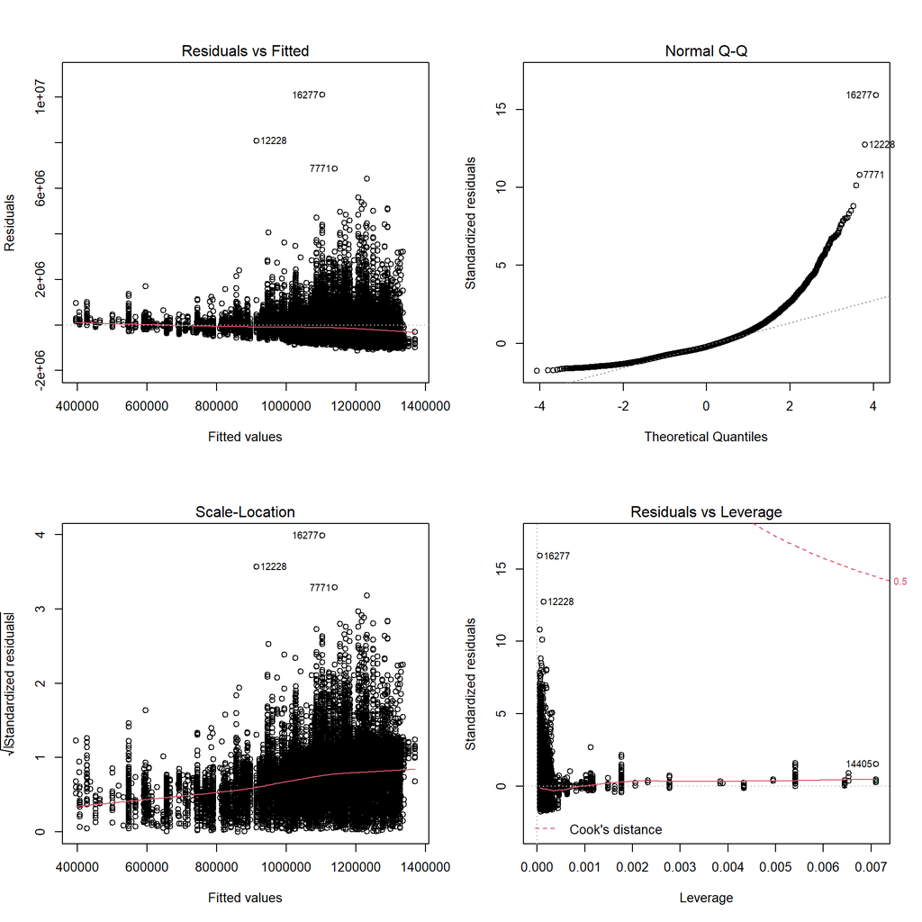

```r
par(mfrow = c(2, 2))
plot(lm.fit2)
```

In order to create a cubic fit, we can include a predictor of the form `I(X^3)`. However, this approach can start to get cumbersome for higher-order polynomials. A better approach involves using the `poly()` function to create the polynomial within `lm()`. For example, the following command produces a fifth-order polynomial fit:

```r
lm.fit5 <- lm(price ~ poly(distance, 5))
summary(lm.fit5)
```

```
##
## Call:
## lm(formula = price ~ poly(distance, 5))
##
## Residuals:
##      Min       1Q   Median       3Q      Max
## -1162602  -386228  -136505   237029 10053259
##
## Coefficients:
##                     Estimate Std. Error t value Pr(>|t|)
## (Intercept)          1089746       4361 249.898  < 2e-16 ***
## poly(distance, 5)1 -22271737     631830 -35.250  < 2e-16 ***
## poly(distance, 5)2   1677491     631830   2.655  0.00794 **
## poly(distance, 5)3   6792303     631830  10.750  < 2e-16 ***
## poly(distance, 5)4  -4993044     631830  -7.903 2.87e-15 ***
## poly(distance, 5)5   1960455     631830   3.103  0.00192 **
## ---
## Signif. codes:  0 '***' 0.001 '**' 0.01 '*' 0.05 '.' 0.1 ' ' 1
##
## Residual standard error: 631800 on 20987 degrees of freedom
## Multiple R-squared:  0.06409,    Adjusted R-squared:  0.06387
## F-statistic: 287.4 on 5 and 20987 DF,  p-value: < 2.2e-16
```

By default, the `poly()` function orthogonalizes the predictors: this means that the features output by this function are not simply a sequence of powers of the argument. However, a linear model applied to the output of the `poly()` function will have the same fitted values as a linear model applied to the raw polynomials (although the coefficient estimates, standard errors, and p-values will differ). In order to obtain the raw polynomials from the `poly()` function, the argument `raw = TRUE` must be used.

Of course, we are in no way restricted to using polynomial transformations of the predictors. Here we try a square root transformation.

```r
summary(lm(price ~ sqrt(distance), data = housing))
```

```
##
## Call:
## lm(formula = price ~ sqrt(distance), data = housing)
##
## Residuals:
##      Min       1Q   Median       3Q      Max
## -1191581  -379263  -147030   235353 10112362
##
## Coefficients:
##                Estimate Std. Error t value Pr(>|t|)
## (Intercept)     1578581      15190  103.92   <2e-16 ***
## sqrt(distance)  -151508       4507  -33.62   <2e-16 ***
## ---
## Signif. codes:  0 '***' 0.001 '**' 0.01 '*' 0.05 '.' 0.1 ' ' 1
##
## Residual standard error: 636100 on 20991 degrees of freedom
## Multiple R-squared:  0.05109,    Adjusted R-squared:  0.05104
## F-statistic:  1130 on 1 and 20991 DF,  p-value: < 2.2e-16
```

# Qualitative Predictors

We will now examine the `Carseats` data, which is part of the `ISLR2` library. We will attempt to predict `Sales` (child car seat sales) in $400$ locations based on a number of predictors.

```r
head(Carseats)
```

```
##   Sales CompPrice Income Advertising Population Price ShelveLoc Age Education
## 1  9.50       138     73          11        276   120       Bad  42        17
## 2 11.22       111     48          16        260    83      Good  65        10
## 3 10.06       113     35          10        269    80    Medium  59        12
## 4  7.40       117    100           4        466    97    Medium  55        14
## 5  4.15       141     64           3        340   128       Bad  38        13
## 6 10.81       124    113          13        501    72       Bad  78        16
##   Urban  US
## 1   Yes Yes
## 2   Yes Yes
## 3   Yes Yes
## 4   Yes Yes
## 5   Yes  No
## 6    No Yes
```

The `Carseats` data includes qualitative predictors such as `shelveloc`, an indicator of the quality of the shelving location—that is, the space within a store in which the car seat is displayed—at each location. The predictor `shelveloc` takes on three possible values: *Bad*, *Medium*, and *Good*. Given a qualitative variable such as `shelveloc`, `R` generates dummy variables automatically. Below we fit a multiple regression model that includes some interaction terms.

```r
lm.fit <- lm(Sales ~ . + Income:Advertising + Price:Age,
    data = Carseats)
summary(lm.fit)
```

```
##
## Call:
## lm(formula = Sales ~ . + Income:Advertising + Price:Age, data = Carseats)
##
## Residuals:
##     Min      1Q  Median      3Q     Max
## -2.9208 -0.7503  0.0177  0.6754  3.3413
##
## Coefficients:
##                      Estimate Std. Error t value Pr(>|t|)
## (Intercept)         6.5755654  1.0087470   6.519 2.22e-10 ***
## CompPrice           0.0929371  0.0041183  22.567  < 2e-16 ***
## Income              0.0108940  0.0026044   4.183 3.57e-05 ***
## Advertising         0.0702462  0.0226091   3.107 0.002030 **
## Population          0.0001592  0.0003679   0.433 0.665330
## Price              -0.1008064  0.0074399 -13.549  < 2e-16 ***
## ShelveLocGood       4.8486762  0.1528378  31.724  < 2e-16 ***
## ShelveLocMedium     1.9532620  0.1257682  15.531  < 2e-16 ***
## Age                -0.0579466  0.0159506  -3.633 0.000318 ***
## Education          -0.0208525  0.0196131  -1.063 0.288361
## UrbanYes            0.1401597  0.1124019   1.247 0.213171
## USYes              -0.1575571  0.1489234  -1.058 0.290729
## Income:Advertising  0.0007510  0.0002784   2.698 0.007290 **
## Price:Age           0.0001068  0.0001333   0.801 0.423812
## ---
## Signif. codes:  0 '***' 0.001 '**' 0.01 '*' 0.05 '.' 0.1 ' ' 1
##
## Residual standard error: 1.011 on 386 degrees of freedom
## Multiple R-squared:  0.8761, Adjusted R-squared:  0.8719
## F-statistic:   210 on 13 and 386 DF,  p-value: < 2.2e-16
```

Using `gtsummary` library to format summary table

```r
library(gtsummary)

lm.fit %>%
     tbl_regression(intercept = TRUE) %>%
     as_gt()
```

| **Characteristic** | **Beta** | **95% CI**<sup>1</sup> | **p-value** |
| --- | --- | --- | --- |
| (Intercept) | 6.6 | 4.6, 8.6 | <0.001 |
| CompPrice | 0.09 | 0.08, 0.10 | <0.001 |
| Income | 0.01 | 0.01, 0.02 | <0.001 |
| Advertising | 0.07 | 0.03, 0.11 | 0.002 |
| Population | 0.00 | 0.00, 0.00 | 0.7 |
| Price | -0.10 | -0.12, -0.09 | <0.001 |
| ShelveLoc |  |  |  |
| Bad | — | — |  |
| Good | 4.8 | 4.5, 5.1 | <0.001 |
| Medium | 2.0 | 1.7, 2.2 | <0.001 |
| Age | -0.06 | -0.09, -0.03 | <0.001 |
| Education | -0.02 | -0.06, 0.02 | 0.3 |
| Urban |  |  |  |
| No | — | — |  |
| Yes | 0.14 | -0.08, 0.36 | 0.2 |
| US |  |  |  |
| No | — | — |  |
| Yes | -0.16 | -0.45, 0.14 | 0.3 |
| Income * Advertising | 0.00 | 0.00, 0.00 | 0.007 |
| Price * Age | 0.00 | 0.00, 0.00 | 0.4 |

<sup>*1*</sup> CI = Confidence Interval

The `contrasts()` function returns the coding that `R` uses for the dummy variables.

```r
attach(Carseats)
contrasts(ShelveLoc)
```

```
##        Good Medium
## Bad       0      0
## Good      1      0
## Medium    0      1
```

Use `?contrasts` to learn about other contrasts, and how to set them.

`R` has created a `ShelveLocGood` dummy variable that takes on a value of 1 if the shelving location is good, and 0 otherwise. It has also created a `ShelveLocMedium` dummy variable that equals 1 if the shelving location is medium, and 0 otherwise. A bad shelving location corresponds to a zero for each of the two dummy variables. The fact that the coefficient for `ShelveLocGood` in the regression output is positive indicates that a good shelving location is associated with high sales (relative to a bad location). And `ShelveLocMedium` has a smaller positive coefficient, indicating that a medium shelving location is associated with higher sales than a bad shelving location but lower sales than a good shelving location.

# Writing Functions

As we have seen, `R` comes with many useful functions, and still more functions are available by way of `R` libraries. However, we will often be interested in performing an operation for which no function is available. In this setting, we may want to write our own function. For instance, below we provide a simple function that reads in the `ISLR2` and `MASS` libraries, called `LoadLibraries()`. Before we have created the function, `R` returns an error if we try to call it.

```r
LoadLibraries
```

```
## Error in eval(expr, envir, enclos): object 'LoadLibraries' not found
```

```r
LoadLibraries()
```

```
## Error in LoadLibraries(): could not find function "LoadLibraries"
```

We now create the function. Note that the `+` symbols are printed by `R` and should not be typed in. The `{` symbol informs `R` that multiple commands are about to be input. Hitting *Enter* after typing `{` will cause `R` to print the `+` symbol. We can then input as many commands as we wish, hitting {*Enter*} after each one. Finally the `}` symbol informs `R` that no further commands will be entered.

```r
LoadLibraries <- function() {
 library(ISLR2)
 library(MASS)
 print("The libraries have been loaded.")
}
```

Now if we type in `LoadLibraries`, `R` will tell us what is in the function.

```r
LoadLibraries
```

```
## function() {
##  library(ISLR2)
##  library(MASS)
##  print("The libraries have been loaded.")
## }
```

If we call the function, the libraries are loaded in and the print statement is output.

```r
LoadLibraries()
```

```
## [1] "The libraries have been loaded."
```